# Final Data Analysis

Hazel Ortiz

12/7/2021

I worked on this assignment with: Justin Maynard, Justin Roch, Aliza Fassler, Sonja Glasser

```r
require(here)
delomys = read.csv(here("data", "delomys.csv"))
```

## Data Exploration

### Numerical Exploration

```r
summary(delomys$body_mass)
```

```
##    Min. 1st Qu.  Median    Mean 3rd Qu.    Max.
##    5.00   35.00   43.00   44.06   54.00  105.00
```

```r
summary(delomys$body_length)
```

```
##    Min. 1st Qu.  Median    Mean 3rd Qu.    Max.
##    49.0   106.0   116.0   114.7   124.0   265.0
```

```r
shapiro.test(delomys$body_mass)
```

```
##
##  Shapiro-Wilk normality test
##
## data:  delomys$body_mass
## W = 0.99506, p-value = 4.33e-05
```

```r
shapiro.test(delomys$body_length)
```

```
##
##  Shapiro-Wilk normality test
##
## data:  delomys$body_length
## W = 0.87609, p-value < 2.2e-16
```

### Graphical Exploration

[figure not shown]

```r
plot(x = delomys$body_mass, y = delomys$body_length, main = " Relationship of Delomys Body Length and Body Mass", xlab = "body length (?)", ylab = "body mass (g)")
```

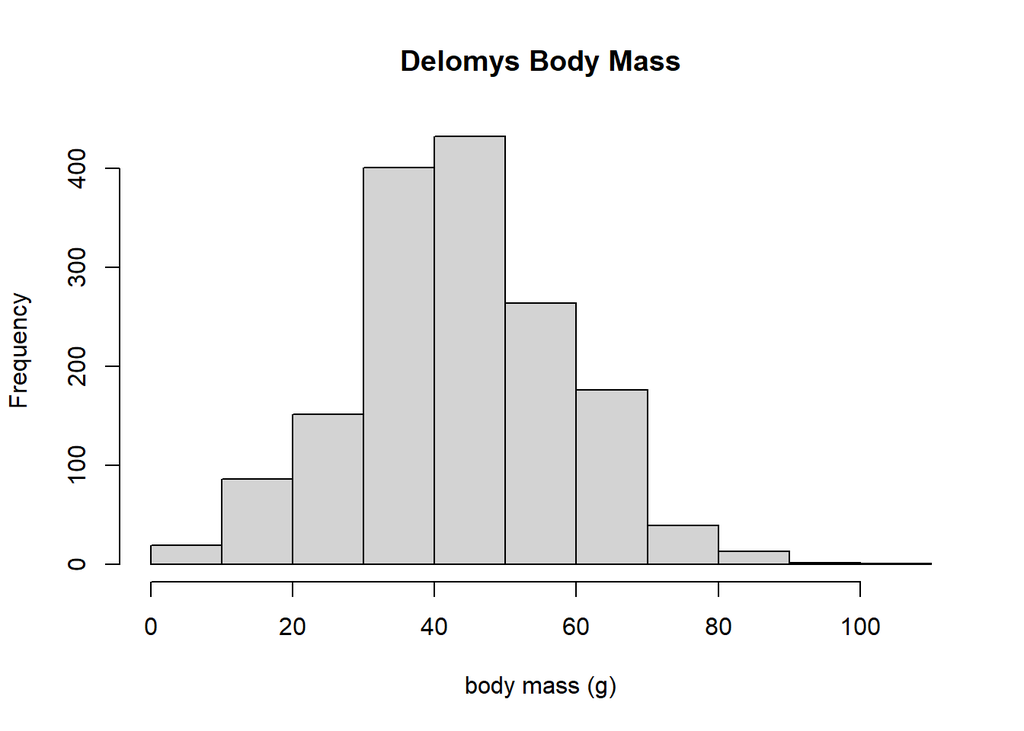

```r
hist(delomys$body_mass, main = "Delomys Body Mass", xlab = "body mass (g)", breaks = 10)
```

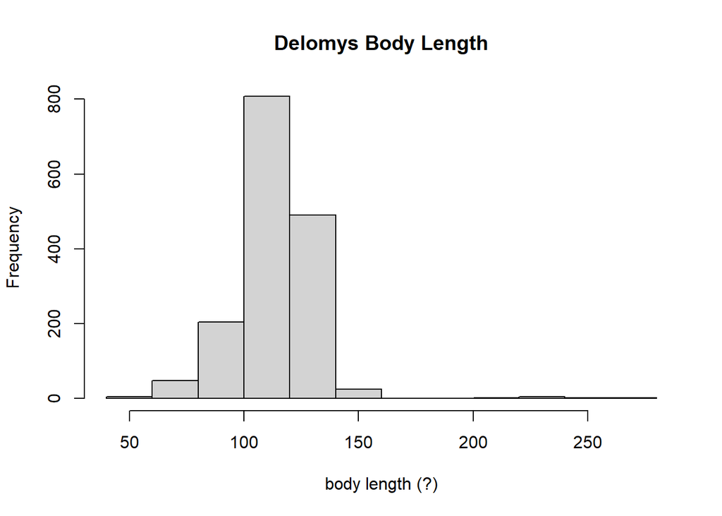

```r
hist(delomys$body_length, main = "Delomys Body Length", xlab = "body length (?)")
```

[figure not shown]

```r
boxplot(body_mass ~ binomial, data = delomys, main = "Delomys Body Length for Species", xlab = "Species", ylab = "body mass (g)")
```

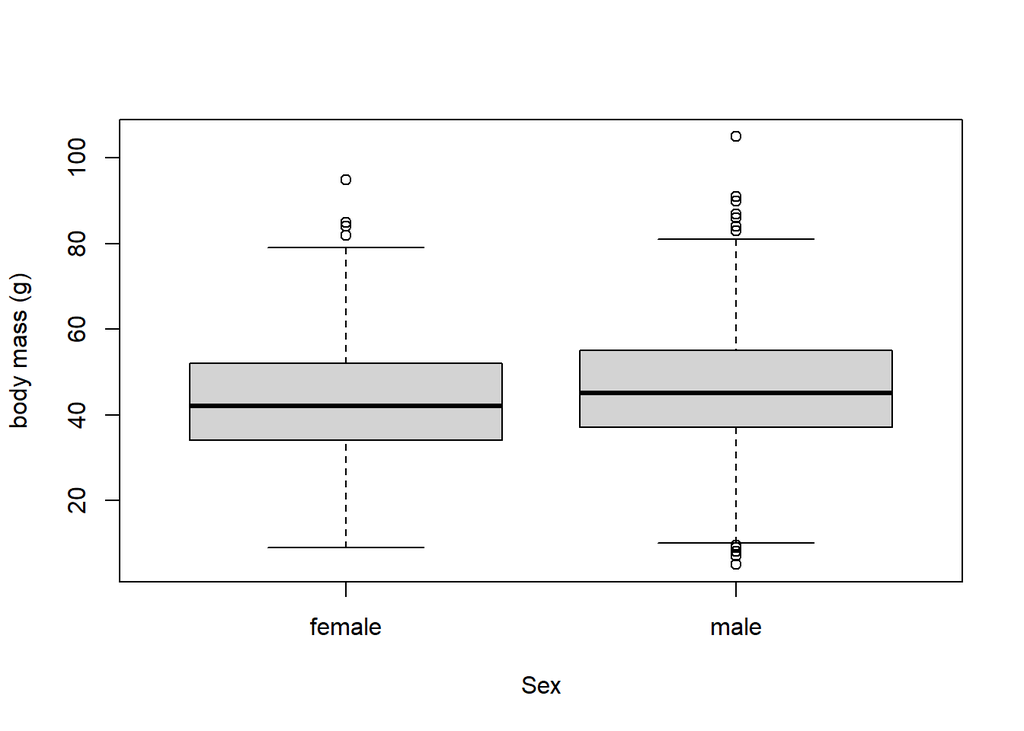

```r
boxplot(body_mass ~ sex, data = delomys, xlab = "Sex", ylab = "body mass (g)")
```

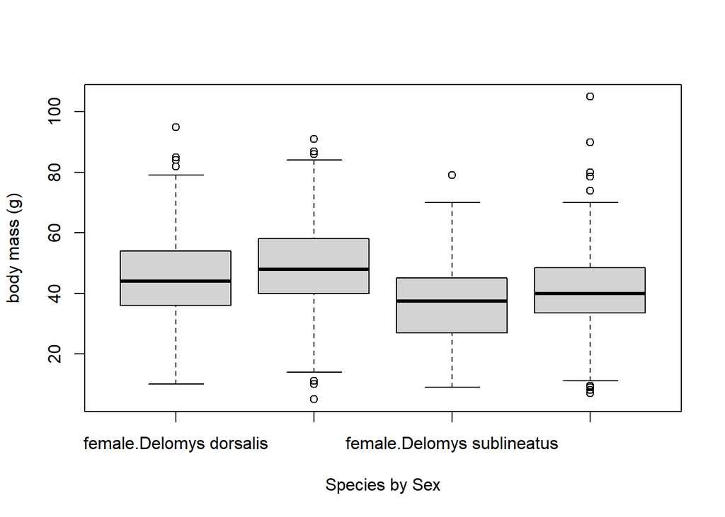

```r
boxplot(body_mass ~ sex + binomial, data = delomys, xlab = "Species by Sex", ylab = "body mass (g)")
```

#### Q1:

The relationship between the body mass and length appears linear. There are a few outliers, and it almost appears there is a very slight curve associated with the data

#### Q2:

These two histograms are not normally distributed. They are skewed in one direction with a larger representation of data towards the left. Body mass seems to be more evenly distributed than length, although still not normally distributed.

#### Q3:

The p-values from the Shapiro test are very small, and the histogram is skewed in one direction. The p-values reject the null hypothesis, meaning that the data is not normally distributed since the Shapiro test null hypothesis is “The data are drawn from a normally-distributed population”. This is supported visually by the histograms, which are skewed.

#### Q4:

By reviewing the boxplot conditioned on species, the body mass appears to be larger with the dorsalis species. Looking at the boxplot conditioned by only sex, it appears that males are slightly larger than females. When conditioned by both variables, there are more patterns being developed regarding their variance and these changes are more reflective in the boxplot. When conditioned by both species and sex, males are larger in both species and the dorsalis species is larger over all than the sublineatus species.

## Model Diagnostics

```r
fit1 = lm(delomys$body_length ~ delomys$body_mass, data = delomys)
fit2 = lm(delomys$body_mass ~ delomys$sex, data = delomys)
fit3 = lm(delomys$body_mass ~ delomys$binomial, data = delomys)
fit4 = lm(delomys$body_mass ~ delomys$sex + delomys$binomial, data = delomys)
fit5 = lm(delomys$body_mass ~ delomys$sex * delomys$binomial, data = delomys)
```

## Residuals

```r
residuals(fit1)
```

[output not shown]

[output cut: 579 more lines]

[output not shown]

```r
residuals(fit2)
```

[output not shown]

[output cut: 577 more lines]

[output not shown]

```r
residuals(fit3)
```

[output not shown]

[output cut: 475 more lines]

[output not shown]

```r
residuals(fit4)
```

[output not shown]

[output cut: 473 more lines]

[output not shown]

```r
residuals(fit5)
```

[output not shown]

[output cut: 473 more lines]

[output not shown]

### Histogram Model Residuals

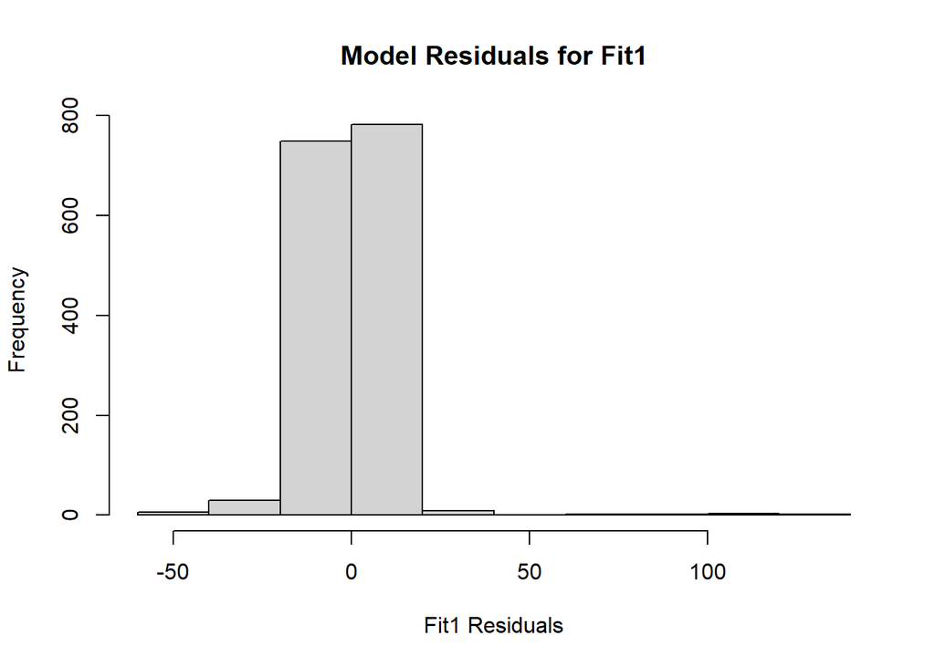

```r
hist(residuals(fit1), main = "Model Residuals for Fit1", xlab = "Fit1 Residuals")
```

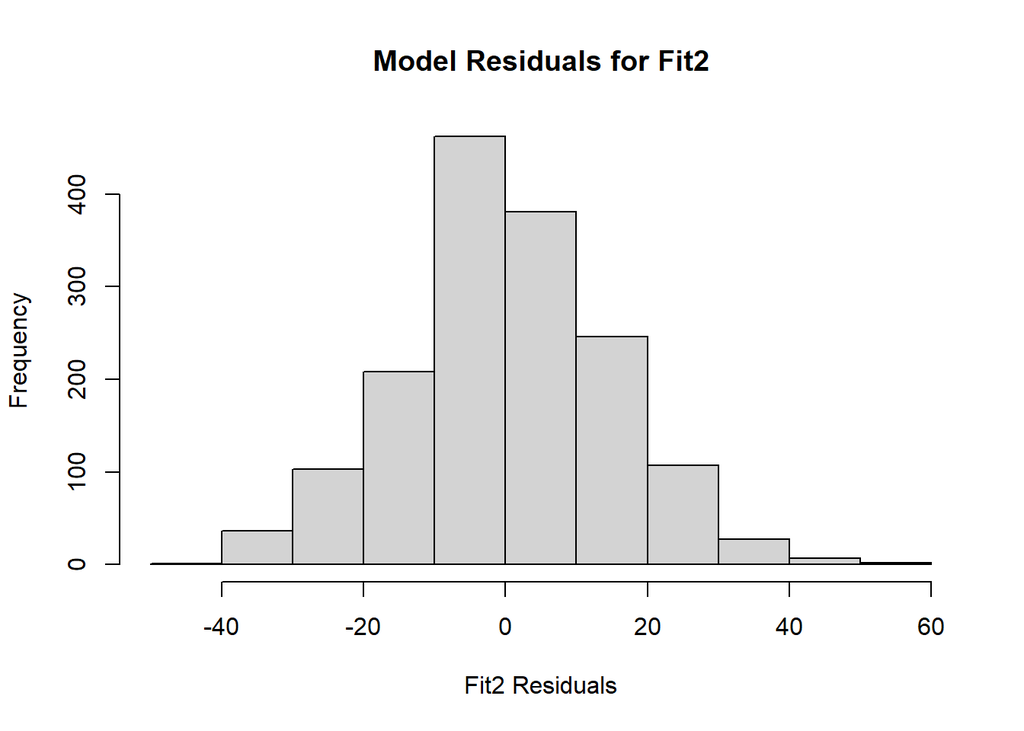

```r
hist(residuals(fit2), main = "Model Residuals for Fit2", xlab = "Fit2 Residuals")
```

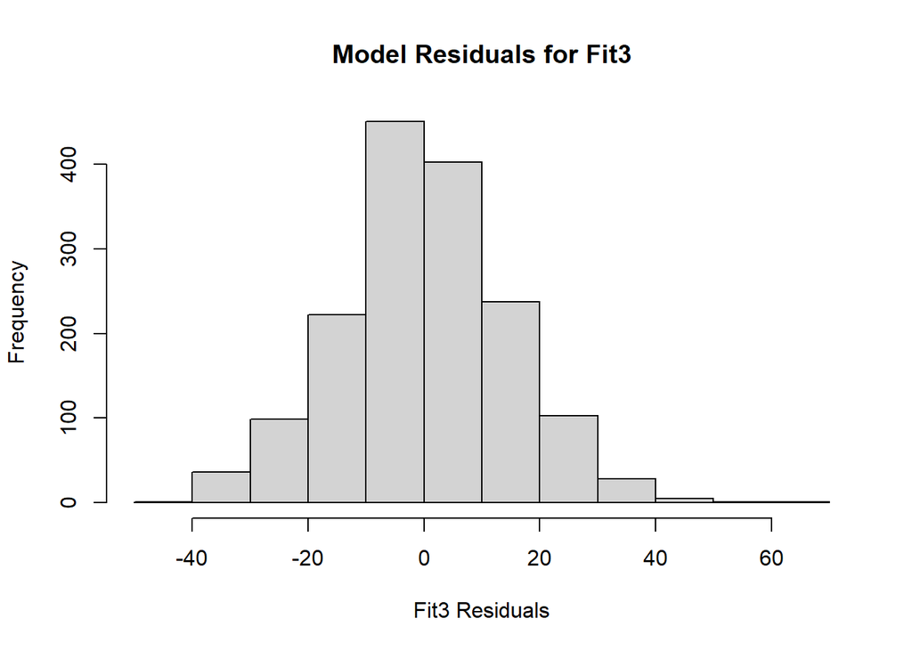

```r
hist(residuals(fit3), main = "Model Residuals for Fit3", xlab = "Fit3 Residuals")
```

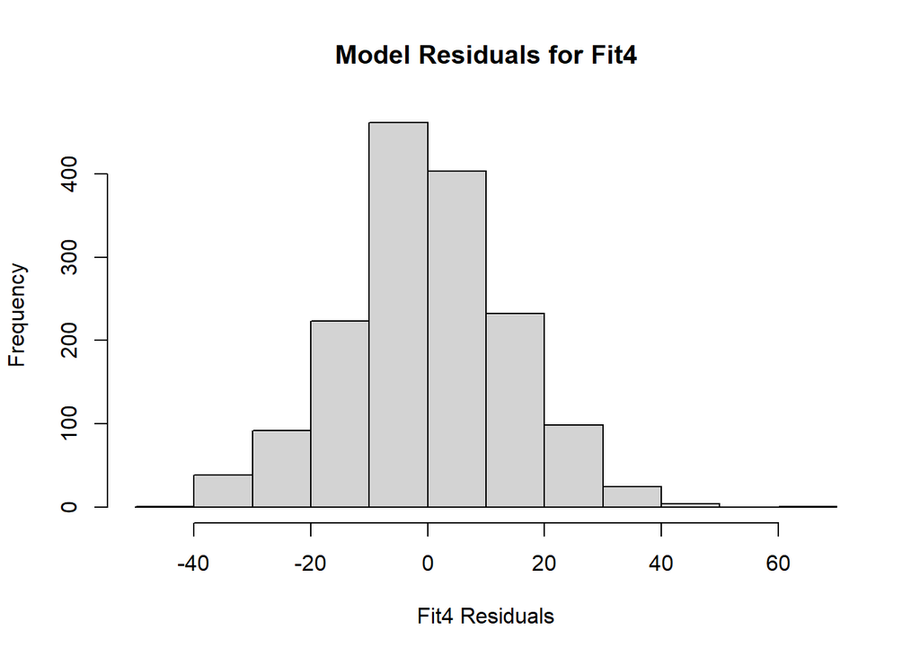

```r
hist(residuals(fit4), main = "Model Residuals for Fit4", xlab = "Fit4 Residuals")
```

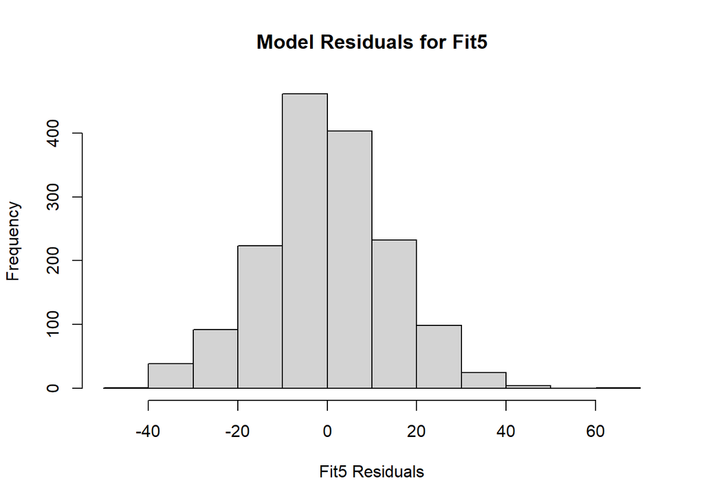

```r
hist(residuals(fit5), main = "Model Residuals for Fit5", xlab = "Fit5 Residuals")
```

### Shapiro Test Model Residuals

```r
shapiro.test(residuals(fit1))
```

```
##
##  Shapiro-Wilk normality test
##
## data:  residuals(fit1)
## W = 0.73462, p-value < 2.2e-16
```

```r
shapiro.test(residuals(fit2))
```

```
##
##  Shapiro-Wilk normality test
##
## data:  residuals(fit2)
## W = 0.99563, p-value = 0.0001541
```

```r
shapiro.test(residuals(fit3))
```

```
##
##  Shapiro-Wilk normality test
##
## data:  residuals(fit3)
## W = 0.99535, p-value = 8.103e-05
```

```r
shapiro.test(residuals(fit4))
```

```
##
##  Shapiro-Wilk normality test
##
## data:  residuals(fit4)
## W = 0.99525, p-value = 6.805e-05
```

```r
shapiro.test(residuals(fit5))
```

```
##
##  Shapiro-Wilk normality test
##
## data:  residuals(fit5)
## W = 0.99526, p-value = 6.816e-05
```

#### Q5:

The numerical data (Shapiro test) show that the models are not normally distributed but the histograms (except for fit1) visually appear they are normally distributed.

#### Q6:

No. Fit 2 is the least severe violation because it has the largest p-value when looking at the Shapiro test.

## Model Interpretation

```r
summary(fit1)
```

```
##
## Call:
## lm(formula = delomys$body_length ~ delomys$body_mass, data = delomys)
##
## Residuals:
##     Min      1Q  Median      3Q     Max
## -48.888  -5.398   0.104   4.859 138.663
##
## Coefficients:
##                   Estimate Std. Error t value Pr(>|t|)
## (Intercept)       76.12466    0.91581   83.12   <2e-16 ***
## delomys$body_mass  0.87550    0.01969   44.46   <2e-16 ***
## ---
## Signif. codes:  0 '***' 0.001 '**' 0.01 '*' 0.05 '.' 0.1 ' ' 1
##
## Residual standard error: 11.67 on 1583 degrees of freedom
## Multiple R-squared:  0.5553, Adjusted R-squared:  0.5551
## F-statistic:  1977 on 1 and 1583 DF,  p-value: < 2.2e-16
```

```r
summary(fit2)
```

```
##
## Call:
## lm(formula = delomys$body_mass ~ delomys$sex, data = delomys)
##
## Residuals:
##     Min      1Q  Median      3Q     Max
## -40.496  -8.711  -0.496   9.504  59.504
##
## Coefficients:
##                 Estimate Std. Error t value Pr(>|t|)
## (Intercept)      42.7115     0.5289  80.756  < 2e-16 ***
## delomys$sexmale   2.7841     0.7456   3.734 0.000195 ***
## ---
## Signif. codes:  0 '***' 0.001 '**' 0.01 '*' 0.05 '.' 0.1 ' ' 1
##
## Residual standard error: 14.82 on 1578 degrees of freedom
##   (5 observations deleted due to missingness)
## Multiple R-squared:  0.008758,   Adjusted R-squared:  0.00813
## F-statistic: 13.94 on 1 and 1578 DF,  p-value: 0.0001951
```

```r
summary(fit3)
```

```
##
## Call:
## lm(formula = delomys$body_mass ~ delomys$binomial, data = delomys)
##
## Residuals:
##     Min      1Q  Median      3Q     Max
## -41.752  -9.069  -0.069   9.248  65.931
##
## Coefficients:
##                                     Estimate Std. Error t value Pr(>|t|)
## (Intercept)                          46.7524     0.4500   103.9   <2e-16 ***
## delomys$binomialDelomys sublineatus  -7.6831     0.7605   -10.1   <2e-16 ***
## ---
## Signif. codes:  0 '***' 0.001 '**' 0.01 '*' 0.05 '.' 0.1 ' ' 1
##
## Residual standard error: 14.44 on 1583 degrees of freedom
## Multiple R-squared:  0.06058,    Adjusted R-squared:  0.05998
## F-statistic: 102.1 on 1 and 1583 DF,  p-value: < 2.2e-16
```

```r
summary(fit4)
```

```
##
## Call:
## lm(formula = delomys$body_mass ~ delomys$sex + delomys$binomial,
##     data = delomys)
##
## Residuals:
##     Min      1Q  Median      3Q     Max
## -43.866  -8.866  -0.672   8.930  64.328
##
## Coefficients:
##                                     Estimate Std. Error t value Pr(>|t|)
## (Intercept)                          45.0704     0.5556  81.114  < 2e-16 ***
## delomys$sexmale                       3.7954     0.7260   5.228 1.94e-07 ***
## delomys$binomialDelomys sublineatus  -8.1935     0.7610 -10.767  < 2e-16 ***
## ---
## Signif. codes:  0 '***' 0.001 '**' 0.01 '*' 0.05 '.' 0.1 ' ' 1
##
## Residual standard error: 14.31 on 1577 degrees of freedom
##   (5 observations deleted due to missingness)
## Multiple R-squared:  0.07663,    Adjusted R-squared:  0.07546
## F-statistic: 65.44 on 2 and 1577 DF,  p-value: < 2.2e-16
```

```r
summary(fit5)
```

```
##
## Call:
## lm(formula = delomys$body_mass ~ delomys$sex * delomys$binomial,
##     data = delomys)
##
## Residuals:
##     Min      1Q  Median      3Q     Max
## -43.884  -8.884  -0.647   8.945  64.353
##
## Coefficients:
##                                                     Estimate Std. Error t value
## (Intercept)                                         45.05546    0.60530  74.435
## delomys$sexmale                                      3.82809    0.89667   4.269
## delomys$binomialDelomys sublineatus                 -8.14174    1.12810  -7.217
## delomys$sexmale:delomys$binomialDelomys sublineatus -0.09502    1.52859  -0.062
##                                                     Pr(>|t|)
## (Intercept)                                          < 2e-16 ***
## delomys$sexmale                                     2.08e-05 ***
## delomys$binomialDelomys sublineatus                 8.22e-13 ***
## delomys$sexmale:delomys$binomialDelomys sublineatus     0.95
## ---
## Signif. codes:  0 '***' 0.001 '**' 0.01 '*' 0.05 '.' 0.1 ' ' 1
##
## Residual standard error: 14.31 on 1576 degrees of freedom
##   (5 observations deleted due to missingness)
## Multiple R-squared:  0.07664,    Adjusted R-squared:  0.07488
## F-statistic:  43.6 on 3 and 1576 DF,  p-value: < 2.2e-16
```

## Model Coefficients

```r
knitr::kable(coef(summary(fit1)))
```

|  | Estimate | Std. Error | t value | Pr(>\|t\|) |
| --- | --- | --- | --- | --- |
| (Intercept) | 76.1246565 | 0.9158120 | 83.12258 | 0 |
| delomys$body_mass | 0.8754988 | 0.0196905 | 44.46298 | 0 |

```r
knitr::kable(coef(summary(fit2)))
```

|  | Estimate | Std. Error | t value | Pr(>\|t\|) |
| --- | --- | --- | --- | --- |
| (Intercept) | 42.711465 | 0.5288929 | 80.756355 | 0.0000000 |
| delomys$sexmale | 2.784133 | 0.7456117 | 3.734024 | 0.0001951 |

```r
knitr::kable(coef(summary(fit3)))
```

|  | Estimate | Std. Error | t value | Pr(>\|t\|) |
| --- | --- | --- | --- | --- |
| (Intercept) | 46.752427 | 0.4499933 | 103.89582 | 0 |
| delomys$binomialDelomys sublineatus | -7.683058 | 0.7604562 | -10.10322 | 0 |

```r
knitr::kable(coef(summary(fit4)))
```

[output not shown]

```r
knitr::kable(coef(summary(fit5)))
```

[output not shown]

#### Q8

Equation for 100 grams becomes y = (0.875)100 + 76.124 = 163.624

#### Q9

The expected body length of an animal weighing 0g is 76.12.

Y = mx + b Y = (.875)x + 76.124 = .875 x 0 + 76.124 = 76.124

#### Q10

The base case is female (42.7115)

#### Q11

The base level for the binomial is Demolys dorsalis (46.7524)

#### Q12

Males are heavier (48.8658)

#### Q13

Demolys dorsalis is heavier.

## Body Mass: ANOVA

```r
knitr::kable(anova(fit1))
```

|  | Df | Sum Sq | Mean Sq | F value | Pr(>F) |
| --- | --- | --- | --- | --- | --- |
| delomys$body_mass | 1 | 269388.9 | 269388.9086 | 1976.957 | 0 |
| Residuals | 1583 | 215706.6 | 136.2645 | NA | NA |

```r
knitr::kable(anova(fit2))
```

|  | Df | Sum Sq | Mean Sq | F value | Pr(>F) |
| --- | --- | --- | --- | --- | --- |
| delomys$sex | 1 | 3061.678 | 3061.6779 | 13.94294 | 0.0001951 |
| Residuals | 1578 | 346507.131 | 219.5863 | NA | NA |

```r
knitr::kable(anova(fit3))
```

|  | Df | Sum Sq | Mean Sq | F value | Pr(>F) |
| --- | --- | --- | --- | --- | --- |
| delomys$binomial | 1 | 21289.68 | 21289.6805 | 102.0751 | 0 |
| Residuals | 1583 | 330164.45 | 208.5688 | NA | NA |

```r
knitr::kable(anova(fit4))
```

[output not shown]

```r
knitr::kable(anova(fit5))
```

[output not shown]

#### Q14

Sex and species are both significant predictors for body mass.

#### Q15

There is not a significant interaction between sex and species.

## Model Comparison: Body Mass

```r
AIC(fit2)
```

```
## [1] 13006.8
```

```r
AIC(fit3)
```

```
## [1] 12966.36
```

```r
AIC(fit4)
```

```
## [1] 12896.73
```

```r
AIC(fit5)
```

```
## [1] 12898.72
```

#### Q17

Fit4 (body_mass ~ sex + binomial) and Fit5 (body_mass ~ sex * binomial ) both have the lowest AIC value, with fit4 being the lowest.

#### Q18

I would choose fit 4 because it is an additive model and simpler than the factorial model. Looking at the AIC, fit 4 is slightly smaller making it the more optimal choice as well. The AIC measures goodness of fit and also penalizes for the number of parameters in a model, with the smaller AIC being optimal.